# Tensorflow with R

## Install necessary packages

```r
pkgs <- c("keras", "lime", "rsample", "recipes", "yardstick", "corrr")
install.packages(pkgs)
```

## tidyverse

http://tidyverse.org/

The `tidyverse` packages provide an easy way to **import**, **tidy**, **transform** and **visualize** the data. Some of it’s component R packages are:

- `dplyr`
- `tidyr`
- `readr`
- `ggplot2`

```r
glimpse(churn_data_raw)
```

```
Observations: 7,043
Variables: 21
$ customerID       <chr> "7590-VHVEG", "5575-GNVDE", "3668-QPYBK", "7795-CFOCW", "9237-H...
$ gender           <chr> "Female", "Male", "Male", "Male", "Female", "Female", "Male", "...
$ SeniorCitizen    <dbl> 0, 0, 0, 0, 0, 0, 0, 0, 0, 0, 0, 0, 0, 0, 0, 0, 0, 0, 0, 0, 1, ...
$ Partner          <chr> "Yes", "No", "No", "No", "No", "No", "No", "No", "Yes", "No", "...
$ Dependents       <chr> "No", "No", "No", "No", "No", "No", "Yes", "No", "No", "Yes", "...
$ tenure           <dbl> 1, 34, 2, 45, 2, 8, 22, 10, 28, 62, 13, 16, 58, 49, 25, 69, 52,...
$ PhoneService     <chr> "No", "Yes", "Yes", "No", "Yes", "Yes", "Yes", "No", "Yes", "Ye...
$ MultipleLines    <chr> "No phone service", "No", "No", "No phone service", "No", "Yes"...
$ InternetService  <chr> "DSL", "DSL", "DSL", "DSL", "Fiber optic", "Fiber optic", "Fibe...
$ OnlineSecurity   <chr> "No", "Yes", "Yes", "Yes", "No", "No", "No", "Yes", "No", "Yes"...
$ OnlineBackup     <chr> "Yes", "No", "Yes", "No", "No", "No", "Yes", "No", "No", "Yes",...
$ DeviceProtection <chr> "No", "Yes", "No", "Yes", "No", "Yes", "No", "No", "Yes", "No",...
$ TechSupport      <chr> "No", "No", "No", "Yes", "No", "No", "No", "No", "Yes", "No", "...
$ StreamingTV      <chr> "No", "No", "No", "No", "No", "Yes", "Yes", "No", "Yes", "No", ...
$ StreamingMovies  <chr> "No", "No", "No", "No", "No", "Yes", "No", "No", "Yes", "No", "...
$ Contract         <chr> "Month-to-month", "One year", "Month-to-month", "One year", "Mo...
$ PaperlessBilling <chr> "Yes", "No", "Yes", "No", "Yes", "Yes", "Yes", "No", "Yes", "No...
$ PaymentMethod    <chr> "Electronic check", "Mailed check", "Mailed check", "Bank trans...
$ MonthlyCharges   <dbl> 29.85, 56.95, 53.85, 42.30, 70.70, 99.65, 89.10, 29.75, 104.80,...
$ TotalCharges     <dbl> 29.85, 1889.50, 108.15, 1840.75, 151.65, 820.50, 1949.40, 301.9...
$ Churn            <chr> "No", "No", "Yes", "No", "Yes", "Yes", "No", "No", "Yes", "No",...
```

## rsample

https://tidymodels.github.io/rsample/

`rsample` contains a set of functions that can create different types of resamples and corresponding classes for their analysis. The goal is to have a modular set of methods that can be used across different R packages for:

traditional resampling techniques for estimating the sampling distribution of a statistic and estimating model performance using a holdout set

```r
library(rsample)

set.seed(100)

train_test_split <- initial_split(
  churn_data_raw,
  prop = 0.3)

train_tbl <- training(train_test_split)
test_tbl  <- testing(train_test_split)
```

## recipes

https://tidymodels.github.io/recipes/

The `recipes` package is an alternative method for creating and preprocessing design matrices that can be used for modeling or visualization.

```r
library(recipes)

rec_obj <- train_tbl %>%
  recipe(Churn ~ .) %>%
  step_rm(customerID) %>%
  step_naomit(all_outcomes(), all_predictors()) %>%
  step_discretize(tenure, options = list(cuts = 6)) %>%
  step_log(TotalCharges) %>%
  step_mutate(Churn = ifelse(Churn == "Yes", 1, 0)) %>%
  step_dummy(all_nominal(), -all_outcomes()) %>%
  step_center(all_predictors(), -all_outcomes()) %>%
  step_scale(all_predictors(), -all_outcomes()) %>%
  prep()

summary(rec_obj)
```

| variable | type | role | source |
| --- | --- | --- | --- |
| SeniorCitizen | numeric | predictor | original |
| MonthlyCharges | numeric | predictor | original |
| TotalCharges | numeric | predictor | original |
| Churn | numeric | outcome | original |
| gender_Male | numeric | predictor | derived |
| Partner_Yes | numeric | predictor | derived |
| Dependents_Yes | numeric | predictor | derived |
| tenure_bin1 | numeric | predictor | derived |
| tenure_bin2 | numeric | predictor | derived |
| tenure_bin3 | numeric | predictor | derived |

[output cut: 26 more lines]

Save the recipe file into the Shiny folder for later use

```r
save(rec_obj, file = "../shiny-app/rec_obj.RData")
```

Use `juice()` to extarct the results from the model preparation. The predictor and outcome data are processed separately. This is because how Keras expects these arguments to be used when fitting a model.

```r
x_train_tbl <- juice(rec_obj, all_predictors(), composition = "matrix")
y_train_vec <- juice(rec_obj, all_outcomes()) %>% pull()
```

The same is done with the testing data so that the two can be compared.

```r
baked_test <- bake(rec_obj, test_tbl)

x_test_tbl <- baked_test %>%
  select(-Churn) %>%
  as.matrix()

y_test_vec <- baked_test %>%
  select(Churn) %>%
  pull()
```

## Install Tensorflow & Keras

https://tensorflow.rstudio.com/tensorflow/articles/installation.html

https://tensorflow.rstudio.com/keras/#installation

```r
library(tensorflow)
library(keras)

#install_tensorflow()
#install_keras()
```

### Create Neural Network

```r
model_keras <- keras_model_sequential() %>%
  layer_dense(
    units = 16,
    kernel_initializer = "uniform",
    activation = "relu",
    input_shape = ncol(x_train_tbl)) %>%
  layer_dropout(rate = 0.1) %>%
  layer_dense(
    units = 16,
    kernel_initializer = "uniform",
    activation = "relu") %>%
  layer_dropout(rate = 0.1) %>%
  layer_dense(
    units = 1,
    kernel_initializer = "uniform",
    activation = "sigmoid") %>%
  compile(
    optimizer = 'adam',
    loss = 'binary_crossentropy',
    metrics = c('accuracy')
  )

model_keras
```

```
Model
_____________________________________________________________________________________________
Layer (type)                             Output Shape                          Param #
=============================================================================================
dense_1 (Dense)                          (None, 16)                            576
_____________________________________________________________________________________________
dropout_1 (Dropout)                      (None, 16)                            0
_____________________________________________________________________________________________
dense_2 (Dense)                          (None, 16)                            272
_____________________________________________________________________________________________
dropout_2 (Dropout)                      (None, 16)                            0
_____________________________________________________________________________________________
dense_3 (Dense)                          (None, 1)                             17
=============================================================================================
Total params: 865
Trainable params: 865
Non-trainable params: 0
_____________________________________________________________________________________________
```

### Fit model

```r
# Fit the keras model to the training data
history <- fit(
  object = model_keras,
  x = x_train_tbl,
  y = y_train_vec,
  batch_size = 50,
  epochs = 35,
  validation_split = 0.30,
  verbose = 0
)
```

```
2019-03-13 13:43:31.622924: I T:\src\github\tensorflow\tensorflow\core\platform\cpu_feature_guard.cc:141] Your CPU supports instructions that this TensorFlow binary was not compiled to use: AVX2
```

```r
print(history)
```

```
Trained on 1,478 samples, validated on 634 samples (batch_size=50, epochs=35)
Final epoch (plot to see history):
val_loss: 0.4457
 val_acc: 0.7981
    loss: 0.3909
     acc: 0.816
```

### Preview results

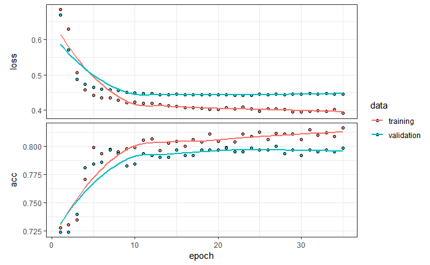

```r
theme_set(theme_bw())

# Plot the training/validation history of our Keras model
plot(history)
```

```r
# Predicted Class
yhat_keras_class_vec <- model_keras %>%
  predict_classes(x_test_tbl) %>%
  as.factor() %>%
  fct_recode(yes = "1", no = "0")

# Predicted Class Probability
yhat_keras_prob_vec  <- model_keras %>%
  predict_proba(x_test_tbl) %>%
  as.vector()

test_truth <- y_test_vec %>%
  as.factor() %>%
  fct_recode(yes = "1", no = "0")

# Format test data and predictions for yardstick metrics
estimates_keras_tbl <- tibble(
  truth      = test_truth,
  estimate   = yhat_keras_class_vec,
  class_prob = yhat_keras_prob_vec
)

estimates_keras_tbl
```

| truth | estimate | class_prob |
| --- | --- | --- |
| no | yes | 0.6718079448 |
| yes | no | 0.2516337931 |
| yes | yes | 0.7327568531 |
| yes | yes | 0.7501937747 |
| no | yes | 0.5538581610 |
| no | no | 0.1532818526 |
| yes | yes | 0.5771296024 |
| no | no | 0.0042885724 |
| no | no | 0.1562065929 |
| no | no | 0.0072721527 |

[output cut: 990 more lines]

## yardstick

https://tidymodels.github.io/yardstick/

`yardstick` is a package to estimate how well models are working using tidy data principals.

```r
library(yardstick)

options(yardstick.event_first = FALSE)

# Confusion Table
estimates_keras_tbl %>%
  conf_mat(truth, estimate)
```

```
          Truth
Prediction   no  yes
       no  3247  564
       yes  378  731
```

```r
# Accuracy
estimates_keras_tbl %>%
  metrics(truth, estimate)
```

| .metric | .estimator | .estimate |
| --- | --- | --- |
| accuracy | binary | 0.8085366 |
| kap | binary | 0.4824736 |

```r
# AUC
estimates_keras_tbl %>%
  roc_auc(truth, class_prob)
```

| .metric | .estimator | .estimate |
| --- | --- | --- |
| roc_auc | binary | 0.8444714 |

```r
# Precision
estimates_keras_tbl %>%
  precision(truth, estimate) %>%
  bind_rows(
    estimates_keras_tbl %>%
      recall(truth, estimate)
  )
```

| .metric | .estimator | .estimate |
| --- | --- | --- |
| precision | binary | 0.6591524 |
| recall | binary | 0.5644788 |

```r
# F1-Statistic
estimates_keras_tbl %>%
  f_meas(truth, estimate, beta = 1)
```

| .metric | .estimator | .estimate |
| --- | --- | --- |
| f_meas | binary | 0.6081531 |

## lime

https://github.com/thomasp85/lime

The purpose of `lime` is to explain the predictions of black box classifiers. What this means is that for any given prediction and any given classifier it is able to determine a small set of features in the original data that has driven the outcome of the prediction.

```r
library(lime)

model_type.keras.engine.sequential.Sequential <- function(x, ...) {
  "classification"
}
# Setup lime::predict_model() function for keras
predict_model.keras.engine.sequential.Sequential <- function(x, newdata, type, ...) {
  pred <- predict_proba(object = x, x = as.matrix(newdata))
  data.frame(Yes = pred, No = 1 - pred)
}
```

```r
# Test our predict_model() function
model_keras %>%
  predict_model(x_test_tbl, "raw") %>%
  as_tibble()
```

| Yes | No |
| --- | --- |
| 0.6718079448 | 0.3281921 |
| 0.2516337931 | 0.7483662 |
| 0.7327568531 | 0.2672431 |
| 0.7501937747 | 0.2498062 |
| 0.5538581610 | 0.4461418 |
| 0.1532818526 | 0.8467181 |
| 0.5771296024 | 0.4228704 |
| 0.0042885724 | 0.9957114 |
| 0.1562065929 | 0.8437934 |
| 0.0072721527 | 0.9927278 |

[output cut: 990 more lines]

```r
library(lime)

# Run lime() on training set
explainer <- x_train_tbl %>%
  as_tibble() %>%
  lime(model_keras,
       bin_continuous = FALSE)

# Run explain() on explainer
explanation <-  x_train_tbl %>%
  as.data.frame() %>%
  head(40) %>%
  lime::explain(
    explainer    = explainer,
    n_labels     = 1,
    n_features   = 4,
    kernel_width = 0.5
    )
```

[figure not shown]

```r
plot_explanations(explanation) +
  labs(title = "LIME Feature Importance Heatmap",
       subtitle = "Hold Out (Test) Set, First 40 Cases Shown")
```